# ggbetweenstats

Indrajeet Patil

2018-09-30

The function `ggstatsplot::ggbetweenstats` is designed not just to facilitate **data exploration**, but also for making **publication-ready box-violin plot**, with all statistical details included in the plot itself. We will see examples of how to use this function in this vignette.

To begin with, here are some instances where you would want to use `ggbetweenstats`-

- to check if a continuous variable differs between multiple groups/conditions
- to check for outliers

**Note before**: The following demo uses the pipe operator (`%>%`), so in case you are not familiar with this operator, here is a good explanation: http://r4ds.had.co.nz/pipes.html

## Between-subjects comparisons with `ggbetweenstats`

To illustrate how this function can be used, we will use the `gapminder` dataset. This dataset provides values for life expectancy, GDP per capita, and population, every five years, from 1952 to 2007, for each of 142 countries and was collected by the Gapminder Foundation. Let’s have a look at the data-

```r
library(gapminder)
library(dplyr)

dplyr::glimpse(x = gapminder::gapminder)
```

```
#> Observations: 1,704
#> Variables: 6
#> $ country   <fct> Afghanistan, Afghanistan, Afghanistan, Afghanistan, ...
#> $ continent <fct> Asia, Asia, Asia, Asia, Asia, Asia, Asia, Asia, Asia...
#> $ year      <int> 1952, 1957, 1962, 1967, 1972, 1977, 1982, 1987, 1992...
#> $ lifeExp   <dbl> 28.801, 30.332, 31.997, 34.020, 36.088, 38.438, 39.8...
#> $ pop       <int> 8425333, 9240934, 10267083, 11537966, 13079460, 1488...
#> $ gdpPercap <dbl> 779.4453, 820.8530, 853.1007, 836.1971, 739.9811, 78...
```

Suppose the first thing we want to check is the distribution of life expectancy worldwide (across continents, i.e.) in 2007. That is, we want to see if the average (across countries in a given continent) life expectancy differs significantly across five continents.

The simplest form of the function call is-

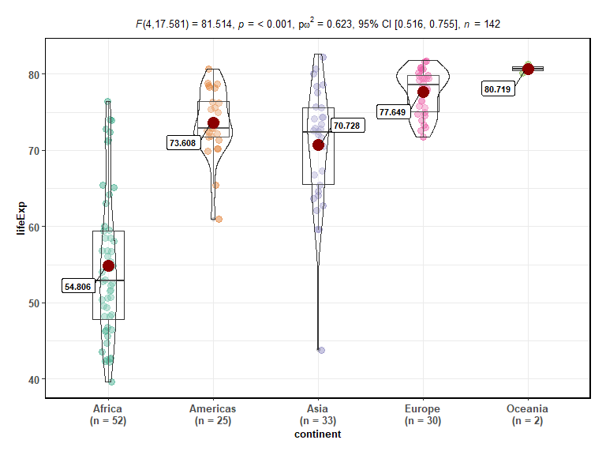

```r
# loading the necessary libraries
library(ggstatsplot)
library(gapminder)

# since the confidence intervals for the effect sizes are computed using
# bootstrapping, important to set a seed for reproducibility
set.seed(123)

# function call
ggstatsplot::ggbetweenstats(
  data = dplyr::filter(.data = gapminder, year == 2007),
  x = continent,
  y = lifeExp,
  messages = FALSE
)
```

Note that the test automatically figures out whether independent t-test is to be run or an ANOVA based on the number of levels in the grouping variable. Additionally, the function output a `ggplot` object which means that it can be further modified.

We will see how this basic call can be further modified with additional arguments-

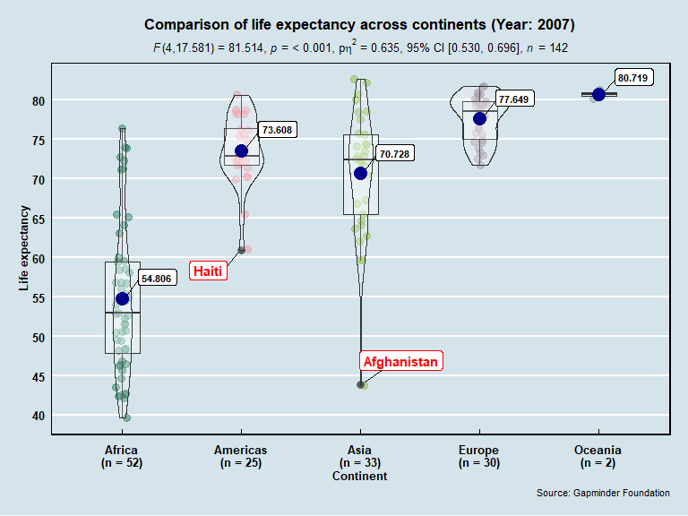

```r
library(ggstatsplot)
library(gapminder)

# for reproducibility
set.seed(123)

ggstatsplot::ggbetweenstats(
  data = dplyr::filter(.data = gapminder, year == 2007),      # dataframe
  x = continent,                                              # grouping/independent variable
  y = lifeExp,                                                # dependent variables
  xlab = "Continent",                                         # label for the x-axis
  ylab = "Life expectancy",                                   # label for the y-axis
  plot.type = "boxviolin",                                    # type of plot
  type = "parametric",                                        # type of statistical test
  effsize.type = "biased",                                    # type of effect size
  outlier.tagging = TRUE,                                     # whether outliers should be flagged
  outlier.coef = 1.5,                                         # coefficient for Tukey's rule
  outlier.label = country,                                    # label to attacht to outlier values
  outlier.label.color = "red",                                # outlier point label color
  mean.plotting = TRUE,                                       # whether the mean is to be displayed
  mean.color = "darkblue",                                    # color for mean
  messages = FALSE,                                           # turn off messages
  ggtheme = ggthemes::theme_economist(),                      # a different theme
  package = "yarrr",                                          # package for a color palette
  palette = "info2",                                          # choosing a color palette
  title = "Comparison of life expectancy across continents (Year: 2007)",
  caption = "Source: Gapminder Foundation"
) +                                                           # modifying the plot further
  ggplot2::scale_y_continuous(limits = c(35,85), breaks = seq(from = 35, to = 85, by = 5))
```

As can be appreciated from the effect size of 0.635, there are big differences in the observed life expectancy across continents. Importantly, this plot also helps us appreciate the differences within any given continent. For example, although Asian countries are doing much better than African countries, on average, Afghanistan has a particularly grim average for the Asian continent, possibly reflecting the war and the political turmoil.

Out of curiosity, we can repeat the same analysis with other available feature of `ggstatsplot`:

- The `type` (of test) argument also accepts the following abbreviations:  
  `"p"` (for *parametric*), `"np"` (for *nonparametric*), `"r"` (for *robust*).
- The type of plot to be displayed can also be modified (`"box"`, `"violin"`, or `"boxviolin"`).
- The color palettes can be modified.

For example,

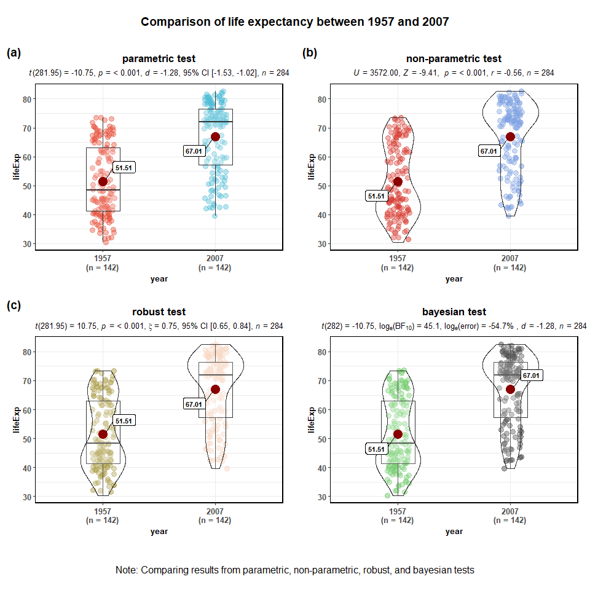

```r
library(ggstatsplot)
library(gapminder)

# selecting subset of the data
df_year <- dplyr::filter(.data = gapminder::gapminder,
                         year == 2007 | year == 1957)

# for reproducibility
set.seed(123)

# parametric ANOVA and box plot
p1 <- ggstatsplot::ggbetweenstats(
  data = df_year,
  x = year,
  y = lifeExp,
  plot.type = "box",
  type = "p",
  effsize.type = "d",
  title = "parametric test",
  package = "ggsci",
  palette = "nrc_npg",
  k = 2,
  messages = FALSE
)

# Kruskal-Wallis test (nonparametric ANOVA) and violin plot
p2 <- ggstatsplot::ggbetweenstats(
  data = df_year,
  x = year,
  y = lifeExp,
  plot.type = "violin",
  type = "np",
  title = "non-parametric test",
  package = "ggsci",
  palette = "uniform_startrek",
  k = 2,
  messages = FALSE
)

# robust ANOVA and boxviolin plot
p3 <- ggstatsplot::ggbetweenstats(
  data = df_year,
  x = year,
  y = lifeExp,
  plot.type = "boxviolin",
  type = "r",
  title = "robust test",
  tr = 0.005,
  package = "wesanderson",
  palette = "Royal2",
  nboot = 15,
  k = 2,
  messages = FALSE
)

# robust ANOVA and boxviolin plot
p4 <- ggstatsplot::ggbetweenstats(
  data = df_year,
  x = year,
  y = lifeExp,
  type = "bf",
  title = "bayesian test",
  package = "palettetown",
  palette = "natu",
  k = 2,
  messages = FALSE
)

# combining the individual plots into a single plot
ggstatsplot::combine_plots(
  p1, p2, p3, p4,
  nrow = 2,
  ncol = 2,
  labels = c("(a)", "(b)", "(c)"),
  title.text = "Comparison of life expectancy between 1957 and 2007",
  caption.text = "Note: Comparing results from parametric, non-parametric, robust, and bayesian tests",
  title.size = 14,
  caption.size = 12
)
```

## Grouped analysis with `grouped_ggbetweenstats`

What if we want to do the same analysis separately for each year for which the data is available, i.e. checking how the differences in life expectancy have changed since this data collection started in 1952 until 2007? In that case, we will have to either write a `for` loop or use `purrr`, both of which are time consuming and can be a bit of a struggle.

`ggstatsplot` provides a special helper function for such instances: `grouped_ggbetweenstats`. This is merely a wrapper function around `ggstatsplot::combine_plots`. It applies `ggbetweenstats` across all **levels** of a specified **grouping variable** and then combines list of individual plots into a single plot. Note that the grouping variable can be anything: conditions in a given study, groups in a study sample, different studies, etc.

Let’s focus on the following years to see these changes for every 20 years: 1967, 1987, 2007.

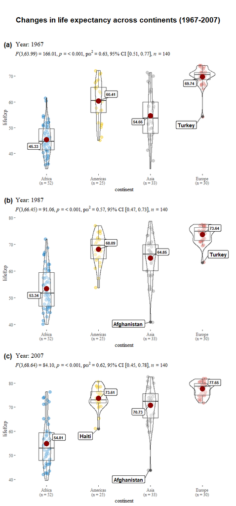

```r
# for reproducibility
set.seed(123)

ggstatsplot::grouped_ggbetweenstats(
  # arguments relevant for ggstatsplot::ggbetweenstats
  data = dplyr::filter(
    .data = gapminder::gapminder,
    year == 1967 |
    year == 1987 |
    year == 2007,
    continent != "Oceania"
  ),
  x = continent,
  y = lifeExp,
  # number of decimal places in results
  k = 2,
  nboot = 10,
  ggtheme = ggthemes::theme_tufte(),
  package = "ggsci",
  palette = "default_jco",
  outlier.tagging = TRUE,
  ggstatsplot.layer = FALSE,
  outlier.label = country,
  grouping.var = year,
  title.prefix = "Year",
  messages = FALSE,
  # arguments relevant for ggstatsplot::combine_plots
  title.text = "Changes in life expectancy across continents (1967-2007)",
  nrow = 3,
  ncol = 1,
  labels = c("(a)","(b)","(c)")
)
```

## Grouped analysis with `ggbetweenstats` + `purrr`

Although this grouping function provides a quick way to explore the data, it leaves much to be desired. For example, the same type of plot and test is applied for all years, but maybe we want to change this for different years, or maybe we want to gave different effect sizes for different years. This type of customization for different levels of a grouping variable is not possible with `grouped_ggbetweenstats`, but this can be easily achieved using the `purrr` package. See the associated vignette here: https://indrajeetpatil.github.io/ggstatsplot/articles/purrr_examples.html

## Within-subjects designs

Variant of this function `ggwithinstats` is currently under work. You *can* still use this function just to prepare the **plot** for exploratory data analysis, but the statistical details displayed in the subtitle will be incorrect. You can remove them by adding `+ ggplot2::labs(subtitle = NULL)`.

# Suggestions

If you find any bugs or have any suggestions/remarks, please file an issue on GitHub: https://github.com/IndrajeetPatil/ggstatsplot/issues

# Session Information

Summarizing session information for reproducibility.

```r
options(width = 200)
devtools::session_info()
```

[output not shown]